# Homework 02

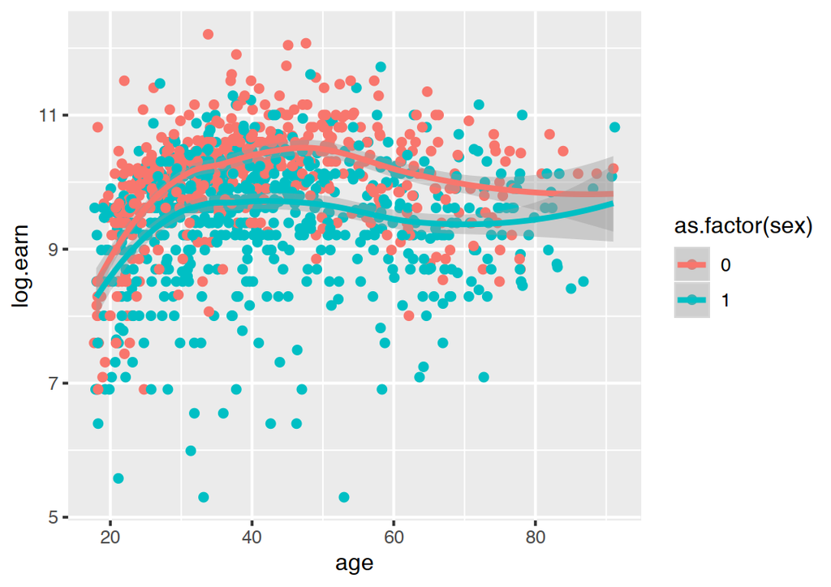

```r
ggplot(h.transformed)+aes(x = age,y = log.earn,color = as.factor(sex))+geom_jitter()+geom_smooth(method='loess')
```

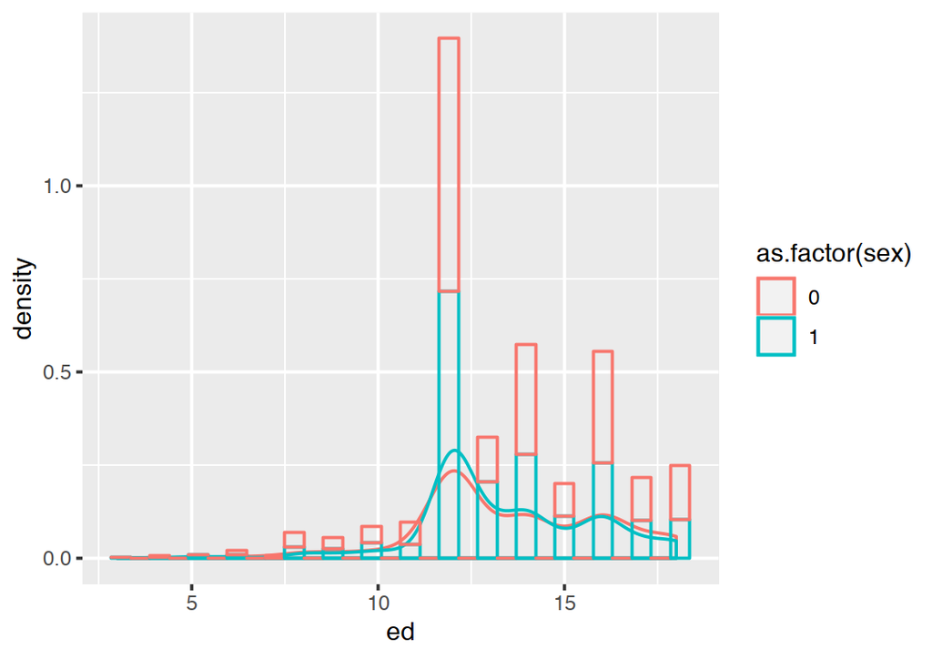

```r
## education
ggplot(h.transformed)+aes(x = ed,color = as.factor(sex))+geom_density( alpha = .4)+geom_histogram(bins = 30,alpha = .4,aes(y=..density..),fill = NA )
```

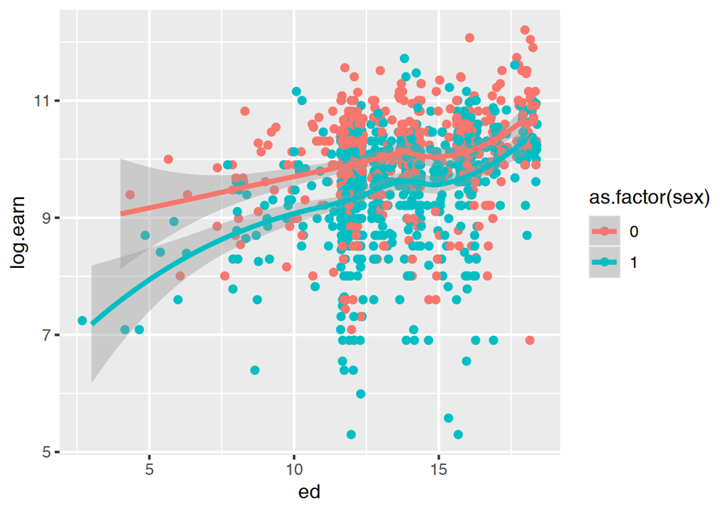

```r
ggplot(h.transformed)+aes(x = ed,y = log.earn,color = as.factor(sex))+geom_jitter()+geom_smooth(method='loess')
```

```r
MD1 = lm(data = h.transformed,log.earn ~ sex + h.centered + sex*h.centered)
summary(MD1)$call
```

```
## lm(formula = log.earn ~ sex + h.centered + sex * h.centered,
##     data = h.transformed)
```

```r
summary(summary(MD1))
```

```
##               Length Class  Mode
## call             3   -none- call
## terms            3   terms  call
## residuals     1192   -none- numeric
## coefficients    16   -none- numeric
## aliased          4   -none- logical
## sigma            1   -none- numeric
## df               3   -none- numeric
## r.squared        1   -none- numeric
## adj.r.squared    1   -none- numeric
## fstatistic       3   -none- numeric
## cov.unscaled    16   -none- numeric
```

```r
summary(MD1)$coef
```

```
##                    Estimate Std. Error    t value     Pr(>|t|)
## (Intercept)     9.946321548 0.05736331 173.391704 0.000000e+00
## sex            -0.419713073 0.07301657  -5.748190 1.145709e-08
## h.centered      0.024454484 0.01330615   1.837834 6.633649e-02
## sex:h.centered -0.007446534 0.01863502  -0.399599 6.895237e-01
```

```r
summary(MD1)$r.squared
```

```
## [1] 0.08668346
```

```r
summary(MD1)$call
```

```
## lm(formula = log.earn ~ sex + h.centered + sex * h.centered,
##     data = h.transformed)
```

```r
summary(MD1)
```

```
##
## Call:
## lm(formula = log.earn ~ sex + h.centered + sex * h.centered,
##     data = h.transformed)
##
## Residuals:
##     Min      1Q  Median      3Q     Max
## -4.2297 -0.3720  0.1388  0.5646  2.2940
##
## Coefficients:
##                 Estimate Std. Error t value Pr(>|t|)
## (Intercept)     9.946322   0.057363 173.392  < 2e-16 ***
## sex            -0.419713   0.073017  -5.748 1.15e-08 ***
## h.centered      0.024454   0.013306   1.838   0.0663 .
## sex:h.centered -0.007447   0.018635  -0.400   0.6895
## ---
## Signif. codes:  0 '***' 0.001 '**' 0.01 '*' 0.05 '.' 0.1 ' ' 1
##
## Residual standard error: 0.8812 on 1188 degrees of freedom
## Multiple R-squared:  0.08668,    Adjusted R-squared:  0.08438
## F-statistic: 37.58 on 3 and 1188 DF,  p-value: < 2.2e-16
```

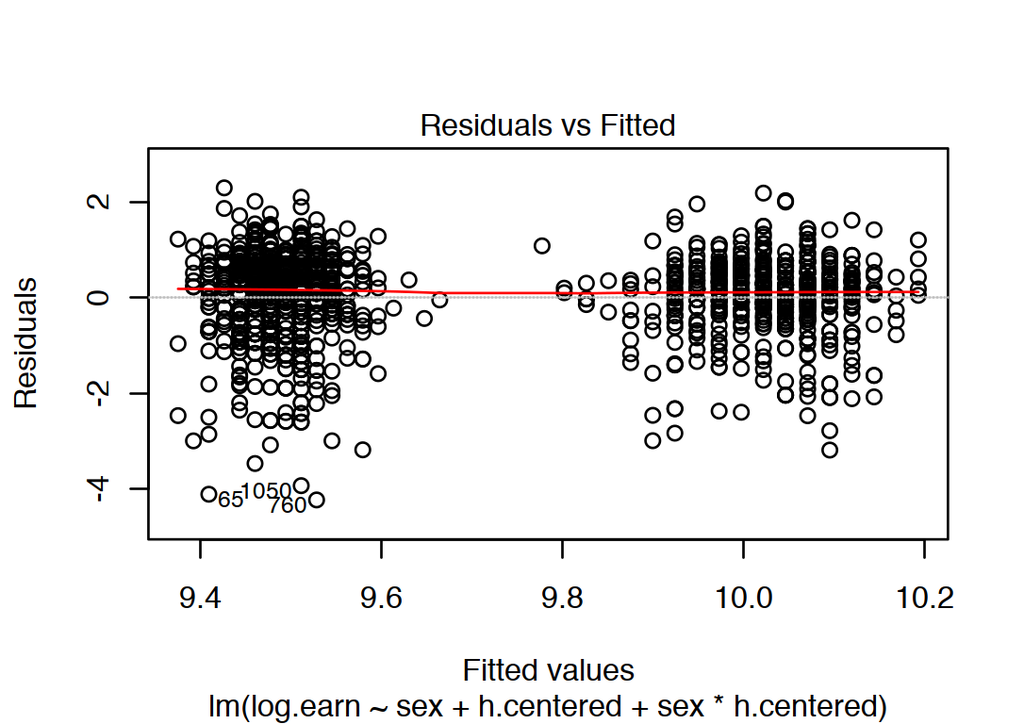

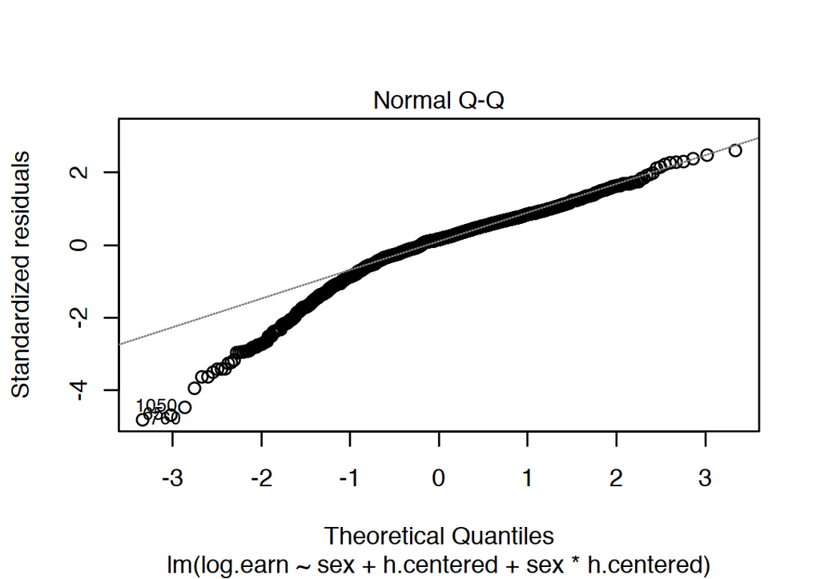

```r
plot(MD1,which=1:2)
```

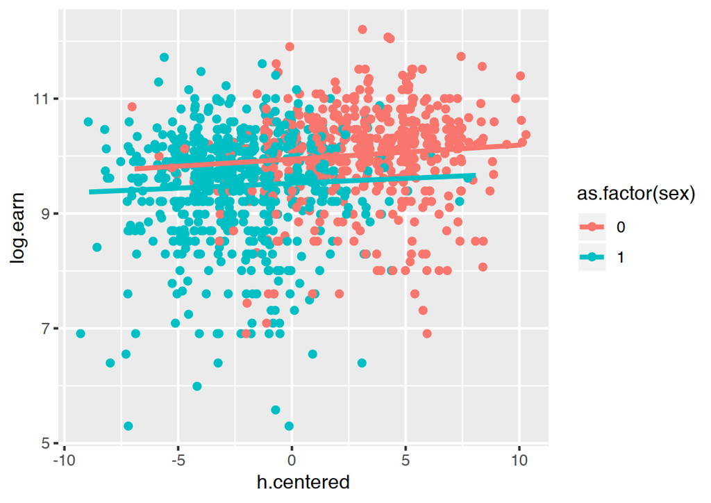

```r
ggplot(h.transformed)+aes(x = h.centered,y = log.earn,color = as.factor(sex))+geom_jitter()+geom_smooth(method='lm',se = F)
```

From the plot shown, the residual show a tiny bias but stays really close to 0, but the variance is quite high and not equal across all the heights. From the QQ-plot we can see that the model works reasonably well for higher height values but have problems with lower height values. From the age vs log.earn plot we can clearly see that there can be a nonlinear relationship between the two, for comparison we construct the model 2 as $y = gender + age + age^2 + gender * age + gender * age^2$.

```r
## substract age with min(age) & add one colomn age^2
h.transformed <- mutate(h.transformed,age = age-min(age))%>%mutate(agesq = age^2)
MD2 = lm(data = h.transformed, log.earn ~ sex + age + agesq + sex*age + sex *agesq)
summary(MD2)$coef[,1]
```

```
##   (Intercept)           sex           age         agesq       sex:age
##  9.0601894067 -0.1091444448  0.0872425976 -0.0013161904 -0.0407576635
##     sex:agesq
##  0.0006137022
```

```r
md2coef <- summary(MD2)$coef[,1]
summary(MD2)$r.squared
```

```
## [1] 0.19855
```

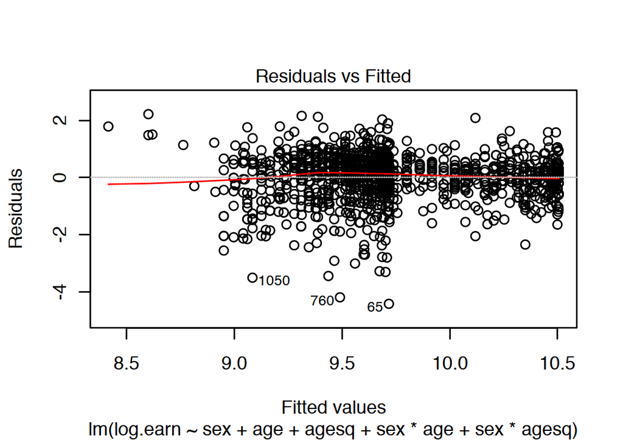

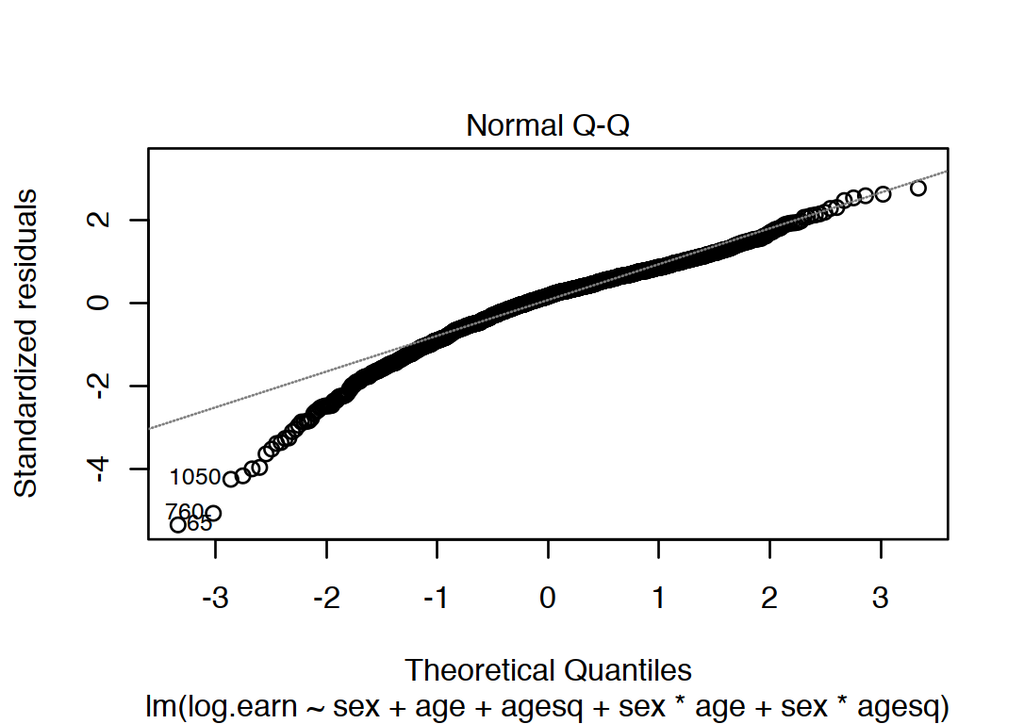

```r
plot(MD2,which = 1:2)
```

4. Interpret all model coefficients. Both models discussed above shows although using different variables, but shows a similar results in residual analysis. Thus, for the purpose of this HW, model 2 using age & gender is selected to interpret here.

```r
kable(t(md2coef),format = 'html',digits = ,align = 'c')
```

| (Intercept) | sex | age | agesq | sex:age | sex:agesq |
| --- | --- | --- | --- | --- | --- |
| 9.060189 | -0.1091444 | 0.0872426 | -0.0013162 | -0.0407577 | 0.0006137 |

```r
kable(exp(t(md2coef)),format = 'html',digits = ,align = 'c')
```

| (Intercept) | sex | age | agesq | sex:age | sex:agesq |
| --- | --- | --- | --- | --- | --- |
| 8605.78 | 0.8966009 | 1.091161 | 0.9986847 | 0.9600618 | 1.000614 |

- $exp(\beta_1) = 0.90$ means at same age, female with minimun age 18 earns 90% of male.
- $exp(\beta_2) = 1.09$ means for male, 1 years older averagely result in 9% increase on earning.
- $exp(\beta_3) = 0.998$ means for male, 1 unit larger in $age^2$ result in 0.2% decrese on earning.
- $exp(\beta_4) = 0.96$ means for female, compare to male, can expect 4% less increase in earning for unit increase in age.
- $exp(\beta_5) = 1.00$ means for female, compare to male, can expect the same 0.2% decrese on earning for unit increase in age^2.
5. Construct 95% confidence interval for all model coefficients and discuss what they mean.

|  | Estimate | Std. Error | t value | Pr(>\|t\|) |
| --- | --- | --- | --- | --- |
| (Intercept) | 9.06 | 0.09 | 96.19 | 0.0 |
| sex | -0.11 | 0.13 | -0.84 | 0.4 |
| age | 0.09 | 0.01 | 11.10 | 0.0 |
| agesq | 0.00 | 0.00 | -10.03 | 0.0 |
| sex:age | -0.04 | 0.01 | -3.88 | 0.0 |
| sex:agesq | 0.00 | 0.00 | 3.58 | 0.0 |

|  | Est | StandardError | lower95CI | upper95CI |
| --- | --- | --- | --- | --- |
| (Intercept) | 9.06 | 0.09 | 8.87 | 9.25 |
| sex | -0.11 | 0.13 | -0.37 | 0.15 |
| age | 0.09 | 0.01 | 0.07 | 0.10 |
| agesq | 0.00 | 0.00 | 0.00 | 0.00 |
| sex:age | -0.04 | 0.01 | -0.06 | -0.02 |
| sex:agesq | 0.00 | 0.00 | 0.00 | 0.00 |

### Analysis of mortality rates and various environmental factors

The folder `pollution` contains mortality rates and various environmental factors from 60 U.S. metropolitan areas from McDonald, G.C. and Schwing, R.C. (1973) ‘Instabilities of regression estimates relating air pollution to mortality’, Technometrics, vol.15, 463-482.

Variables, in order:

- PREC Average annual precipitation in inches
- JANT Average January temperature in degrees F
- JULT Same for July
- OVR65 % of 1960 SMSA population aged 65 or older
- POPN Average household size
- EDUC Median school years completed by those over 22
- HOUS % of housing units which are sound & with all facilities
- DENS Population per sq. mile in urbanized areas, 1960
- NONW % non-white population in urbanized areas, 1960
- WWDRK % employed in white collar occupations
- POOR % of families with income < $3000
- HC Relative hydrocarbon pollution potential
- NOX Same for nitric oxides
- SO@ Same for sulphur dioxide
- HUMID Annual average % relative humidity at 1pm
- MORT Total age-adjusted mortality rate per 100,000

For this exercise we shall model mortality rate given nitric oxides, sulfur dioxide, and hydrocarbons as inputs. This model is an extreme oversimplification as it combines all sources of mortality and does not adjust for crucial factors such as age and smoking. We use it to illustrate log transformations in regression.

```r
gelman_dir   <- "http://www.stat.columbia.edu/~gelman/arm/examples/"
pollution    <- read.dta (paste0(gelman_dir,"pollution/pollution.dta"))
```

1. Create a scatterplot of mortality rate versus level of nitric oxides. Do you think linear regression will fit these data well? Fit the regression and evaluate a residual plot from the regression.

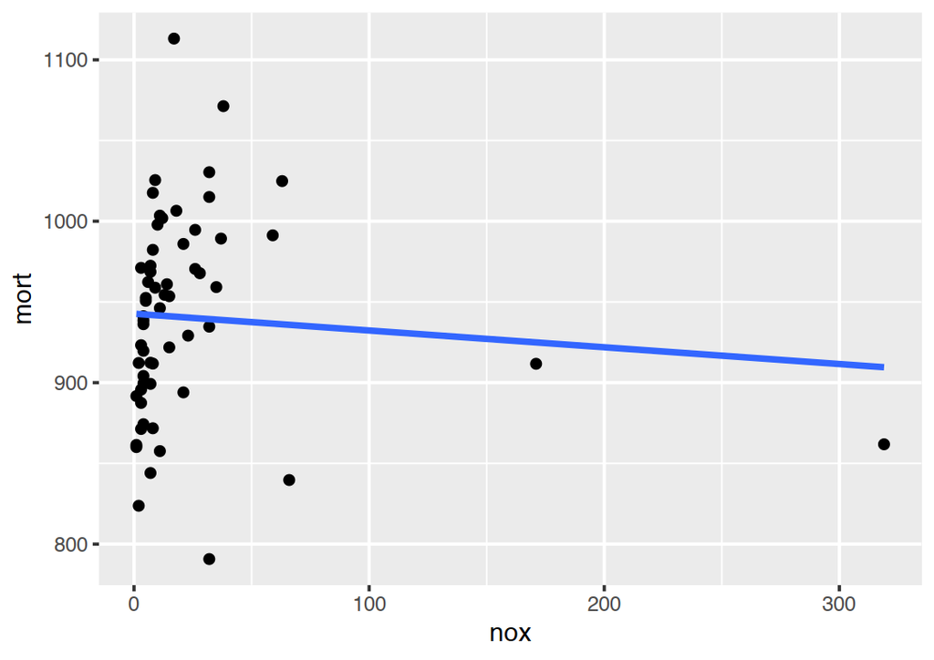

```r
ggplot(pollution)+aes(x = nox,y = mort)+geom_point()+geom_smooth(method = 'lm',se=F)
```

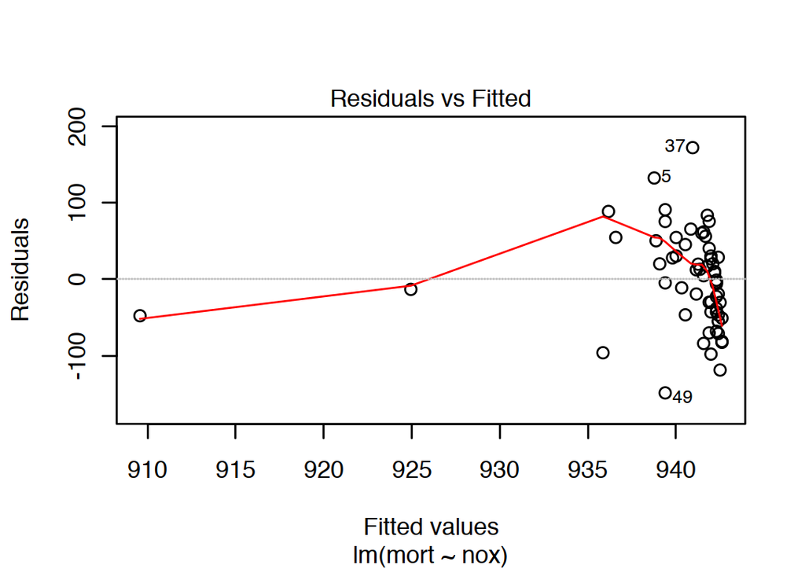

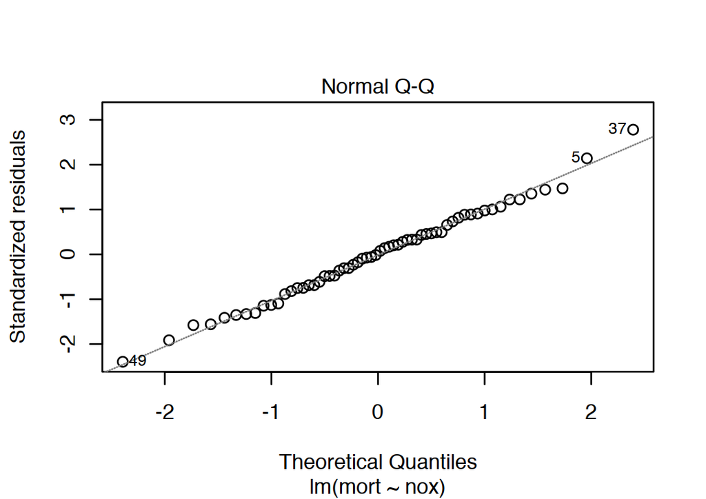

```r
polMD1 = lm(data = pollution, mort ~ nox)
plot(polMD1,which=1:2)
```

```r
summary(polMD1)
```

```
##
## Call:
## lm(formula = mort ~ nox, data = pollution)
##
## Residuals:
##      Min       1Q   Median       3Q      Max
## -148.654  -43.710    1.751   41.663  172.211
##
## Coefficients:
##             Estimate Std. Error t value Pr(>|t|)
## (Intercept) 942.7115     9.0034 104.706   <2e-16 ***
## nox          -0.1039     0.1758  -0.591    0.557
## ---
## Signif. codes:  0 '***' 0.001 '**' 0.01 '*' 0.05 '.' 0.1 ' ' 1
##
## Residual standard error: 62.55 on 58 degrees of freedom
## Multiple R-squared:  0.005987,   Adjusted R-squared:  -0.01115
## F-statistic: 0.3494 on 1 and 58 DF,  p-value: 0.5568
```

Judging from the regression plot and the residual plot, the fit is really bad.

2. Find an appropriate transformation that will result in data more appropriate for linear regression. Fit a regression to the transformed data and evaluate the new residual plot.

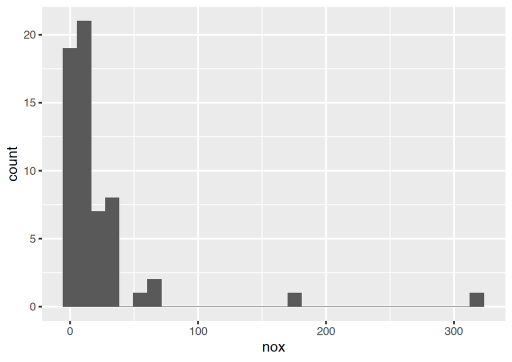

```r
ggplot(pollution)+aes(x = nox)+geom_histogram(bins=30)
```

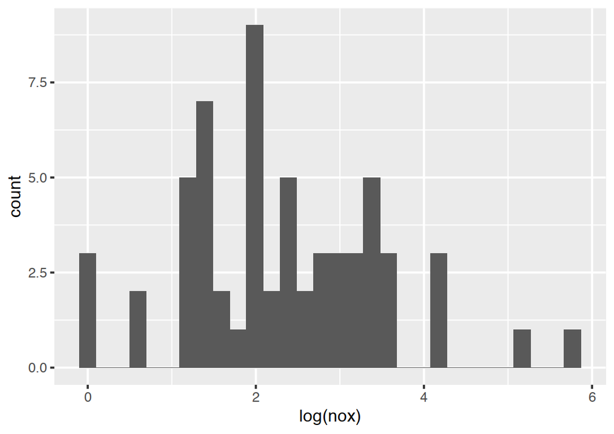

```r
ggplot(pollution)+aes(x = log(nox))+geom_histogram(bins=30)
```

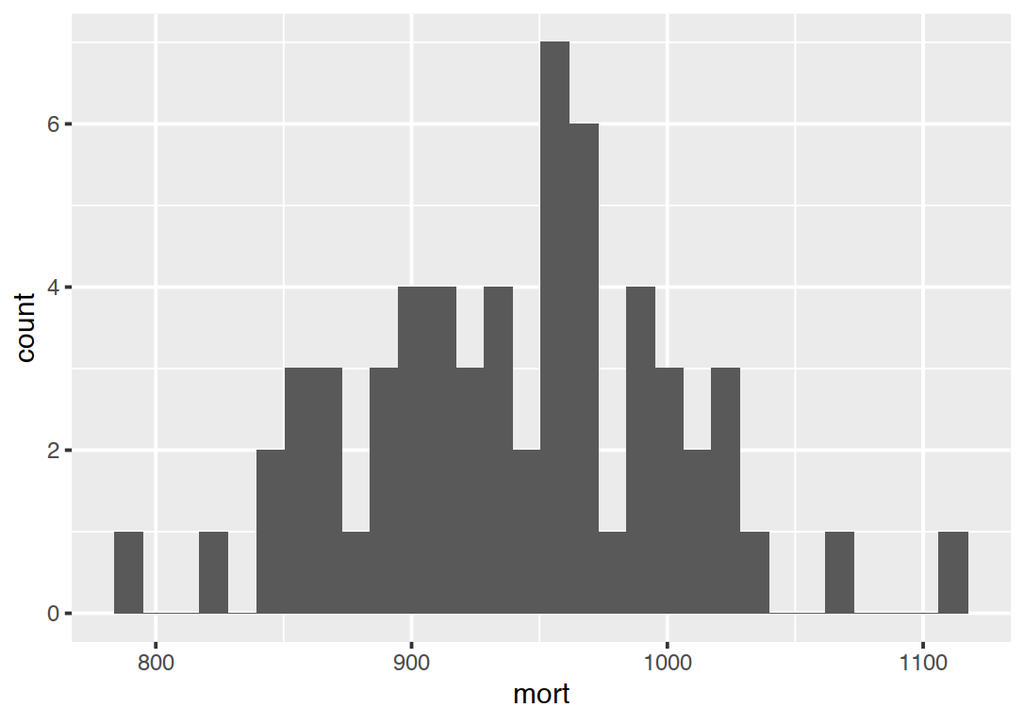

```r
ggplot(pollution)+aes(x = mort)+geom_histogram(bins=30)
```

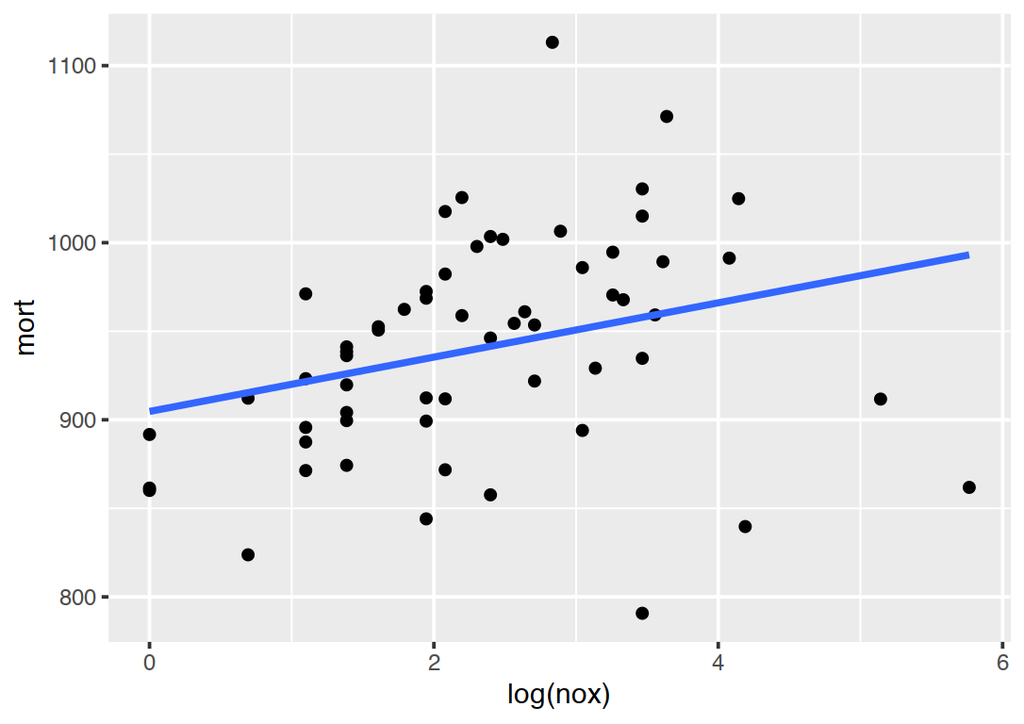

```r
ggplot(pollution)+aes(x=log(nox),y=mort)+geom_point()+geom_smooth(method='lm',se=F)
```

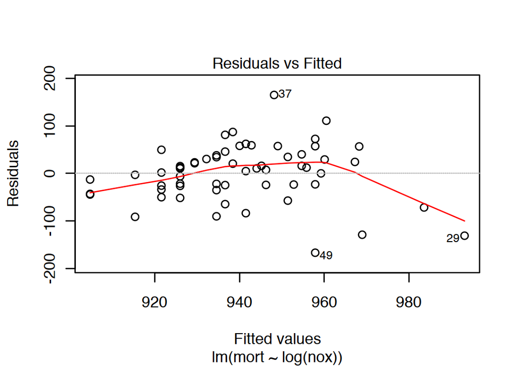

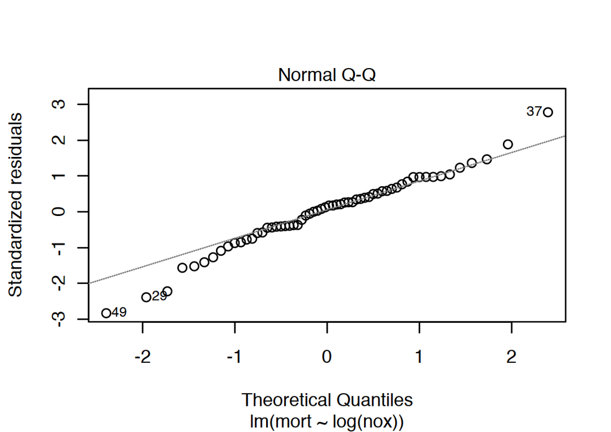

```r
polMD2 = lm(data = pollution, mort ~ log(nox))
plot(polMD2,which=1:2)
```

```r
summary(polMD2)
```

```
##
## Call:
## lm(formula = mort ~ log(nox), data = pollution)
##
## Residuals:
##      Min       1Q   Median       3Q      Max
## -167.140  -28.368    8.778   35.377  164.983
##
## Coefficients:
##             Estimate Std. Error t value Pr(>|t|)
## (Intercept)  904.724     17.173  52.684   <2e-16 ***
## log(nox)      15.335      6.596   2.325   0.0236 *
## ---
## Signif. codes:  0 '***' 0.001 '**' 0.01 '*' 0.05 '.' 0.1 ' ' 1
##
## Residual standard error: 60.01 on 58 degrees of freedom
## Multiple R-squared:  0.08526,    Adjusted R-squared:  0.06949
## F-statistic: 5.406 on 1 and 58 DF,  p-value: 0.02359
```

The new model fits better to the dataset than the previous one. The residual looks better, and the R-square had increased in a factor of 10.

3. Interpret the slope coefficient from the model you chose in 2.

```r
summary(polMD2)
```

```
##
## Call:
## lm(formula = mort ~ log(nox), data = pollution)
##
## Residuals:
##      Min       1Q   Median       3Q      Max
## -167.140  -28.368    8.778   35.377  164.983
##
## Coefficients:
##             Estimate Std. Error t value Pr(>|t|)
## (Intercept)  904.724     17.173  52.684   <2e-16 ***
## log(nox)      15.335      6.596   2.325   0.0236 *
## ---
## Signif. codes:  0 '***' 0.001 '**' 0.01 '*' 0.05 '.' 0.1 ' ' 1
##
## Residual standard error: 60.01 on 58 degrees of freedom
## Multiple R-squared:  0.08526,    Adjusted R-squared:  0.06949
## F-statistic: 5.406 on 1 and 58 DF,  p-value: 0.02359
```

The intercept 904.724 is the mean mortality rate per 100,000 for nox concentration of 1. 4. Construct 99% confidence interval for slope coefficient from the model you chose in 2 and interpret them.

```r
kable(t(c(15.335-3*6.596,15.335+3*6.596)),col.names = c('99%CIlowerbound','99%CIupperbound'),align = 'c',format = 'html')
```

| 99%CIlowerbound | 99%CIupperbound |
| --- | --- |
| -4.453 | 35.123 |

if the same experiment can be done 100 times, one can expect 99 of the times the true slope value lies within the rage of $-4.453$ to $35.123$. 5. Now fit a model predicting mortality rate using levels of nitric oxides, sulfur dioxide, and hydrocarbons as inputs. Use appropriate transformations when helpful. Plot the fitted regression model and interpret the coefficients.

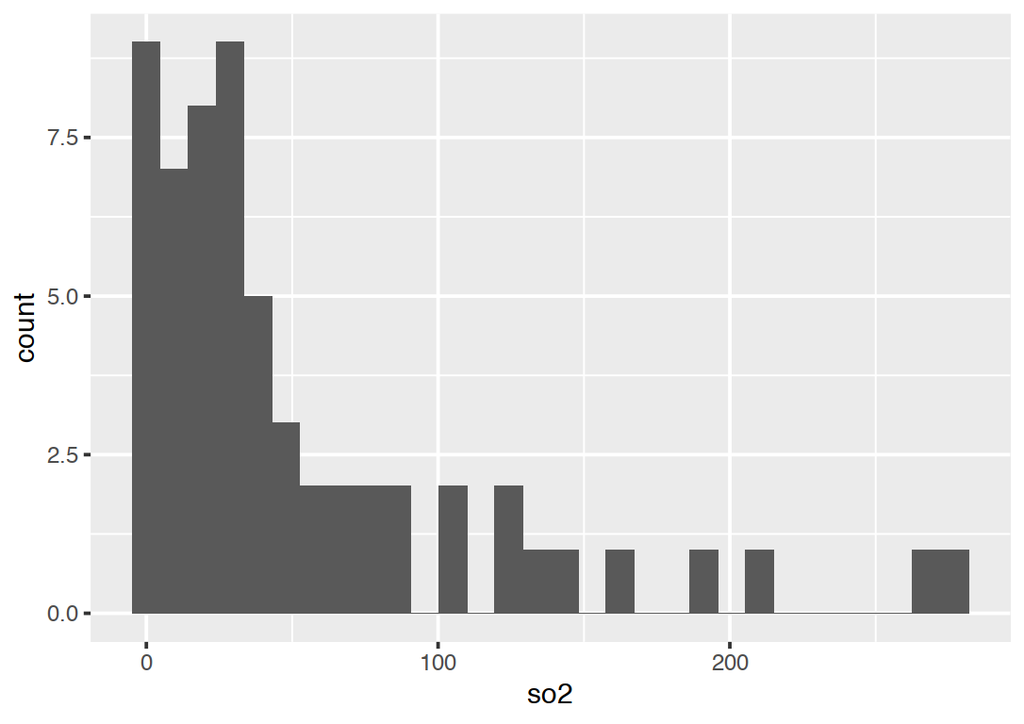

```r
ggplot(pollution)+aes(x = so2)+geom_histogram(bins=30)
```

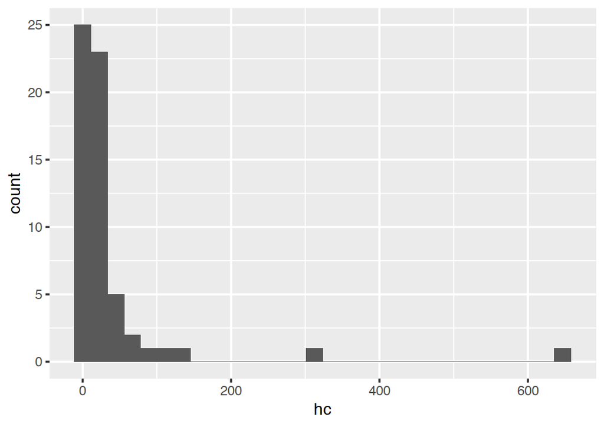

```r
ggplot(pollution)+aes(x = hc)+geom_histogram(bins=30)
```

both $SO^2$ and $HC$ is heavily right skewed, so we can try log transformation:

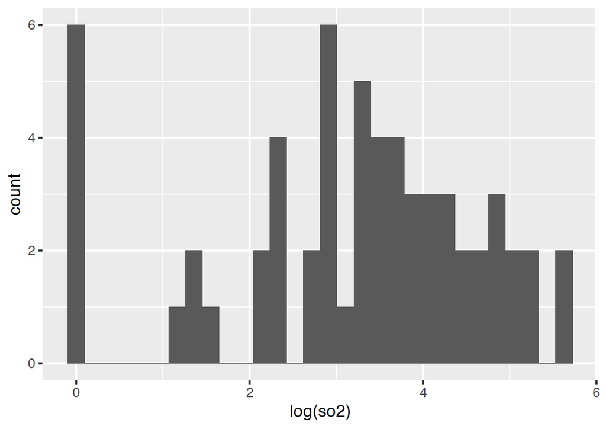

```r
ggplot(pollution)+aes(x = log(so2))+geom_histogram(bins=30)
```

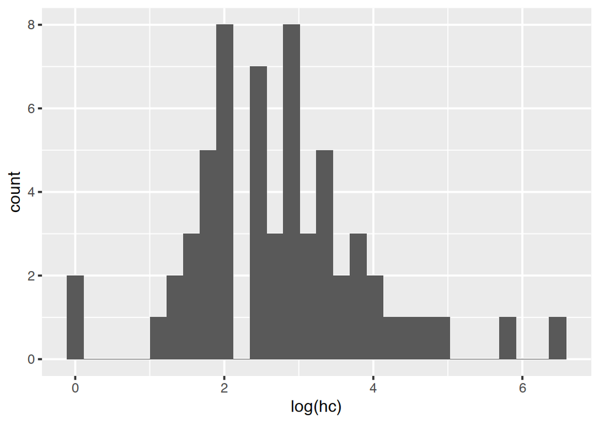

```r
ggplot(pollution)+aes(x = log(hc))+geom_histogram(bins=30)
```

log transformation looks fine, thus we can use this to perform our prediction.

```r
polMD3 = lm(data = pollution, mort ~ log(nox) + log(so2) + log(hc))
summary(polMD3)
```

```
##
## Call:
## lm(formula = mort ~ log(nox) + log(so2) + log(hc), data = pollution)
##
## Residuals:
##     Min      1Q  Median      3Q     Max
## -97.793 -34.728  -3.118  34.148 194.567
##
## Coefficients:
##             Estimate Std. Error t value Pr(>|t|)
## (Intercept)  924.965     21.449  43.125  < 2e-16 ***
## log(nox)      58.336     21.751   2.682  0.00960 **
## log(so2)      11.762      7.165   1.642  0.10629
## log(hc)      -57.300     19.419  -2.951  0.00462 **
## ---
## Signif. codes:  0 '***' 0.001 '**' 0.01 '*' 0.05 '.' 0.1 ' ' 1
##
## Residual standard error: 54.36 on 56 degrees of freedom
## Multiple R-squared:  0.2752, Adjusted R-squared:  0.2363
## F-statistic: 7.086 on 3 and 56 DF,  p-value: 0.0004044
```

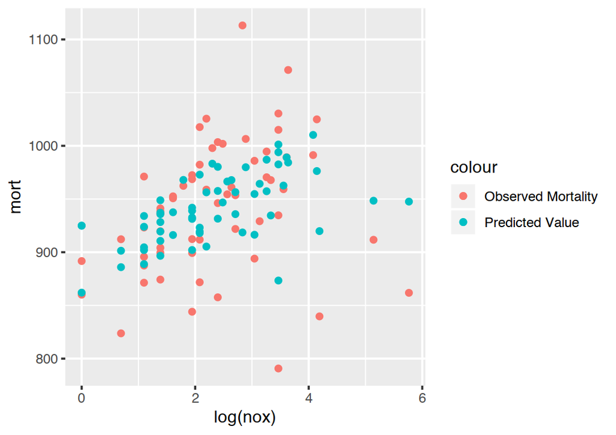

```r
pollution1 = mutate(pollution,predt = predict(polMD3))
ggplot(pollution1)+geom_point(mapping = aes(x = log(nox),y = mort,color = 'Observed Mortality'))+geom_point(mapping = aes(x = log(nox),y = predt,color='Predicted Value'))
```

Under this model, intercept means the average mortality rate is 924.965 per 100,000 people with nox, so2 and hc all equals to 1. coefficient for $\ln nox$ means that for each 1 unit increase in $\ln nox$ one can averagly expect 58.336 increase in mortality rate per 100,000 people coefficient for $\ln so_2$ means that for each 1 unit increase in $\ln so_2$ one can averagly expect 11.762 increase in mortality rate per 100,000 people coefficient for $\ln hc$ means that for each 1 unit increase in $\ln hc$ one can averagly expect 57.300 decrese in mortality rate per 100,000 people 6. Cross-validate: fit the model you chose above to the first half of the data and then predict for the second half. (You used all the data to construct the model in 4, so this is not really cross-validation, but it gives a sense of how the steps of cross-validation can be implemented.)

```r
pol1 = sample_frac(pollution,0.5,replace = F)
pol2 = setdiff(pollution,pol1)%>%select(nox,so2,hc,mort)

polMD4 = lm(data = pol1, mort ~ log(nox) + log(so2) + log(hc))
summary(polMD4)$r.squared
```

```
## [1] 0.6385035
```

```r
pol2 = mutate(pol2, predt = predict(object = polMD4,newdata = pol2))%>%mutate(y = mort - mean(mort))%>%mutate(err = mort - predt)

##R-squared on test set
(1-((pol2$err%*%pol2$err)/(pol2$y%*%pol2$y)))[1]
```

```
## [1] -0.4780497
```

### Study of teenage gambling in Britain

1. Fit a linear regression model with gamble as the response and the other variables as predictors and interpret the coefficients. Make sure you rename and transform the variables to improve the interpretability of your regression model.

```r
## construct log income and log gambling
teengamb1 = mutate(teengamb1,log.in = log(income))%>%mutate(log.gamb = log(gamble))
## choosing log.income and sex to build model
teenMD = lm(data = teengamb1,log.gamb ~ sex + log.in + sex * log.in)
teenMDcoef = exp(as.tibble(summary(teenMD)$coef)[,1])
kable(t(teenMDcoef),format = 'html',digits = 3, align = 'c',col.names = c('Intercept','Gender','Log.in','Gen : Log.in'))
```

|  | Intercept | Gender | Log.in | Gen : Log.in |
| --- | --- | --- | --- | --- |
| Estimate | 2.091 | 1.373 | 3.545 | 0.19 |

```r
kable(summary(teenMD)$coef,format = 'html', digits = 3, align = 'c')
```

|  | Estimate | Std. Error | t value | Pr(>\|t\|) |
| --- | --- | --- | --- | --- |
| (Intercept) | 0.738 | 0.600 | 1.229 | 0.226 |
| sex | 0.317 | 1.224 | 0.259 | 0.797 |
| log.in | 1.265 | 0.392 | 3.232 | 0.003 |
| sex:log.in | -1.659 | 0.828 | -2.005 | 0.052 |

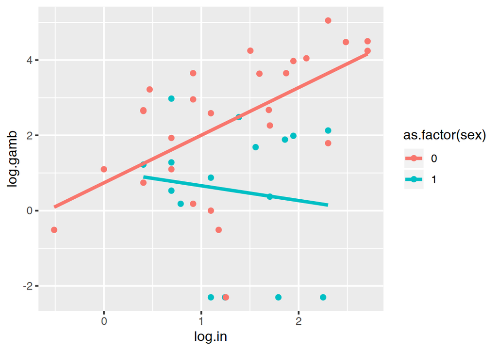

```r
ggplot(teengamb1)+aes(x = log.in, y=log.gamb,color = as.factor(sex))+geom_point()+geom_smooth(method = 'lm',se=F)
```

The intercept means the mean for male with 1 income per week, will gamble 2.091 per year in pounds The coefficient for gender means the for female with 1 income per week is predicted to put 37.3% more on gambling per year The coefficient for log.income means that for male, unit increase in log income per week will increase gambing per year by 254.5% The coefficient for Gen:log.in means that for female, the increase in gambling per year will decrease by 81% compare to male 2. Create a 95% confidence interval for each of the estimated coefficients and discuss how you would interpret this uncertainty.

```r
gambsum = as_tibble(summary(teenMD)$coef)%>%select(1:2)%>%`colnames<-`(c('Est','StandardError'))%>%mutate(lower95CI = Est-2*StandardError)%>%mutate(upper95CI = Est+2*StandardError)%>%`rownames<-`(rownames(summary(teenMD)$coef))
kable(gambsum,format = 'html',digits = 2,align = 'c')
```

|  | Est | StandardError | lower95CI | upper95CI |
| --- | --- | --- | --- | --- |
| (Intercept) | 0.74 | 0.60 | -0.46 | 1.94 |
| sex | 0.32 | 1.22 | -2.13 | 2.77 |
| log.in | 1.27 | 0.39 | 0.48 | 2.05 |
| sex:log.in | -1.66 | 0.83 | -3.31 | 0.00 |

3. Predict the amount that a male with average status, income and verbal score would gamble along with an appropriate 95% CI. Repeat the prediction for a male with maximal values of status, income and verbal score. Which CI is wider and why is this result expected?

```r
teengamb1 = mutate(teengamb1,mean.status = status-mean(status))%>%mutate(mean.logincome = log.in - mean(log.in))%>%mutate(mean.verbal = verbal - mean(verbal))%>%mutate(max.status = status - max(status))%>%mutate(max.logincome = log.in - max(log.in))%>%mutate(max.verbal = verbal - max(verbal))
teenMD2 = lm(data = teengamb1,log.gamb ~ mean.status + mean.logincome + mean.verbal)
teenMD3 = lm(data = teengamb1,log.gamb ~ max.status + max.logincome + max.verbal)
sum1 = t(as_tibble(summary(teenMD2)$coef[1,1:2]))
##lower95CI for mean
sum1[1]-2*sum1[2]
```

```
## [1] 1.129144
```

```r
##upper95CI for mean
sum1[1]+2*sum1[2]
```

```
## [1] 2.238994
```

```r
sum2 = t(as_tibble(summary(teenMD3)$coef[1,1:2]))
##lower95CI for mean
sum2[1]-2*sum2[2]
```

```
## [1] 1.822091
```

```r
##upper95CI for mean
sum2[1]+2*sum2[2]
```

```
## [1] 5.49428
```

The maximal CI is wider, because locally there is fewer points than the mean ones, which results in bigger variance. ### School expenditure and test scores from USA in 1994-95

```r
sat = sat
```

1. Fit a model with total sat score as the outcome and expend, ratio and salary as predictors. Make necessary transformation in order to improve the interpretability of the model. Interpret each of the coefficient.

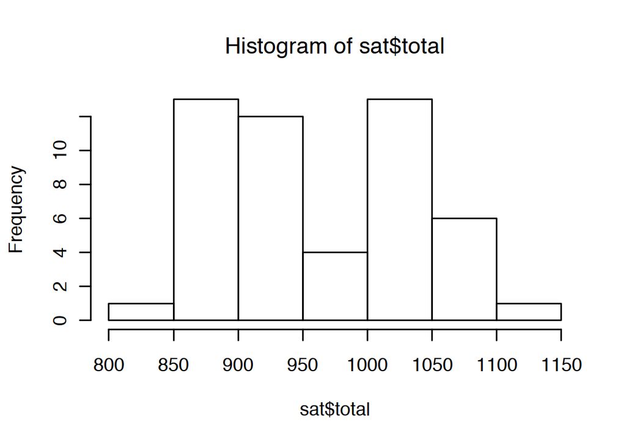

```r
hist(sat$total)
```